# Tools Comparison (Detailed): OpenCode + Kimi K2.5

## Run Metadata

- **Harness:** `opencode`
- **Model:** `kimi-k2-5`
- **Prompt type:** `detailed`

## Setup

```r
# Load and normalize the dataset
df <- readr::read_csv(here::here("data/synthetic/simulated_maternal_health_data.csv"))

# Clean column names to snake_case
df <- df %>% janitor::clean_names()

# Normalize column types
df <- df %>%
  mutate(
    # Convert binary indicators to logical
    received_comprehensive_postnatal_care = as.logical(received_comprehensive_postnatal_care),
    obesity = as.logical(obesity),
    multiple_gestation = as.logical(multiple_gestation),
    diabetes = as.logical(diabetes),
    heart_disease = as.logical(heart_disease),
    placenta_previa = as.logical(placenta_previa),
    hypertension = as.logical(hypertension),
    gest_hypertension = as.logical(gest_hypertension),
    preeclampsia = as.logical(preeclampsia),

    # Convert categorical variables to factors
    state = as.factor(state),
    race_ethnicity = factor(race_ethnicity,
                             levels = c("white", "black", "hispanic", "asian", "aian", "nhpi", "other"),
                             labels = c("White", "Black", "Hispanic", "Asian", "AI/AN", "NH/PI", "Other")),
    insurance = factor(insurance,
                       levels = c("no_insurance", "state_provided", "private"),
                       labels = c("No Insurance", "State Provided", "Private")),
    job_type = factor(job_type),
    edu = factor(edu,
                 levels = c("less_than_hs", "hs", "some_college", "college", "post_grad"),
                 labels = c("< High School", "High School", "Some College", "College", "Post-Grad"),
                 ordered = TRUE),
    self_report_income = factor(self_report_income,
                                levels = c("$0–$24,999", "$25,000–$49,999", "$50,000–$74,999",
                                           "$75,000–$99,999", "$100,000–$149,999", "$150,000–$199,999", "$200,000+"),
                                ordered = TRUE)
  )
```

## Summary of Changes Made

**Data Normalization:** - ✓ Cleaned column names to snake_case format using `janitor::clean_names()` - ✓ Converted binary indicators (0/1) to logical type for clarity - ✓ Converted categorical variables to factors with meaningful labels - ✓ Set ordered factors for education and income levels

## Data Summary

### Dataset Overview

The dataset contains **50,000 records** with **20 columns** after normalization.

```
Rows: 50000
```

```
Columns: 20
```

### Missingness Analysis

Missing Values by Variable

| variable | missing_count | missing_pct |
| --- | --- | --- |
| self_report_income | 3620 | 7.24 |

```
Duplicate rows: 0
```

### Data Quality Flags

```
Quality Checks:
```

```
- Records with age < 15 or > 50: 0
```

```
- Distance range: 0 to 163.42
```

```
- Records with distance > 100: 57
```

```
- Records with negative distance: 0
```

### Key Descriptive Statistics

Numeric Variables Summary

|  | id | provider_id | age | dependents | distance_to_provider |
| --- | --- | --- | --- | --- | --- |
|  | Min. : 1 | Min. : 1.0 | Min. :15.00 | Min. :0.000 | Min. :8.900e-05 |
|  | 1st Qu.:12501 | 1st Qu.:125.0 | 1st Qu.:23.00 | 1st Qu.:2.000 | 1st Qu.:4.096e+00 |
|  | Median :25000 | Median :251.0 | Median :28.00 | Median :2.000 | Median :1.000e+01 |
|  | Mean :25000 | Mean :250.7 | Mean :28.02 | Mean :2.382 | Mean :1.452e+01 |
|  | 3rd Qu.:37500 | 3rd Qu.:375.0 | 3rd Qu.:32.00 | 3rd Qu.:3.000 | 3rd Qu.:2.024e+01 |
|  | Max. :50000 | Max. :500.0 | Max. :44.00 | Max. :8.000 | Max. :1.634e+02 |

```
  race_ethnicity           insurance                edu
 White   :31511   No Insurance  :20810   < High School: 5218
 Black   : 5878   State Provided:11282   High School  :23108
 Hispanic: 8792   Private       :17908   Some College :14959
 Asian   : 3059                          College      : 5269
 AI/AN   :  387                          Post-Grad    : 1446
 NH/PI   :   90
 Other   :  283
```

## Key Visualizations

### 1. Distribution of Comprehensive Postnatal Care Receipt

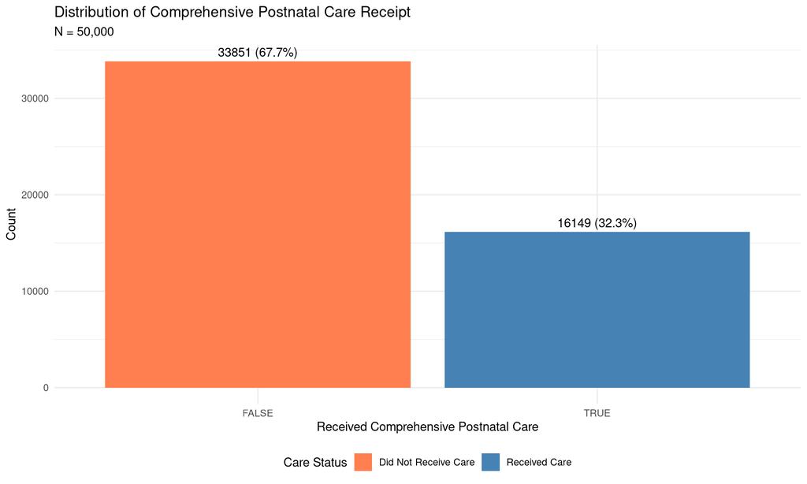

Figure 1: Distribution of comprehensive postnatal care receipt across the sample

```r
df %>%
  count(received_comprehensive_postnatal_care) %>%
  mutate(pct = 100 * n / sum(n)) %>%
  ggplot(aes(x = received_comprehensive_postnatal_care, y = n, fill = received_comprehensive_postnatal_care)) +
  geom_bar(stat = "identity") +
  geom_text(aes(label = sprintf("%d (%.1f%%)", n, pct)), vjust = -0.5) +
  scale_fill_manual(values = c("TRUE" = "steelblue", "FALSE" = "coral"),
                    labels = c("TRUE" = "Received Care", "FALSE" = "Did Not Receive Care")) +
  labs(
    title = "Distribution of Comprehensive Postnatal Care Receipt",
    subtitle = sprintf("N = %s", format(nrow(df), big.mark = ",")),
    x = "Received Comprehensive Postnatal Care",
    y = "Count",
    fill = "Care Status"
  ) +
  theme_minimal() +
  theme(legend.position = "bottom")
```

**Key Finding:** Approximately 32.3% of mothers received comprehensive postnatal care.

### 2. Distance to Healthcare Provider Distribution

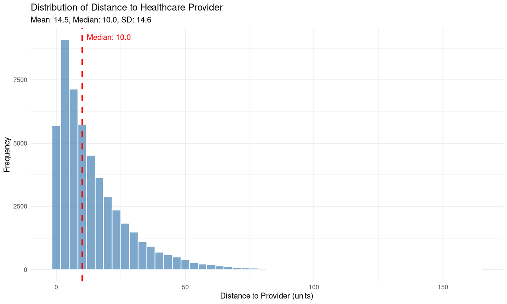

Figure 2: Distribution of distance to healthcare provider with median indicated

```r
df %>%
  ggplot(aes(x = distance_to_provider)) +
  geom_histogram(bins = 50, fill = "steelblue", alpha = 0.7, color = "white") +
  geom_vline(aes(xintercept = median(distance_to_provider)),
             color = "red", linetype = "dashed", linewidth = 1) +
  annotate("text", x = median(df$distance_to_provider), y = Inf,
           label = sprintf("Median: %.1f", median(df$distance_to_provider)),
           vjust = 2, hjust = -0.1, color = "red") +
  labs(
    title = "Distribution of Distance to Healthcare Provider",
    subtitle = sprintf("Mean: %.1f, Median: %.1f, SD: %.1f",
                       mean(df$distance_to_provider),
                       median(df$distance_to_provider),
                       sd(df$distance_to_provider)),
    x = "Distance to Provider (units)",
    y = "Frequency"
  ) +
  theme_minimal()
```

**Key Finding:** Distance to provider is right-skewed with median ~10 units.

### 3. Postnatal Care by Distance (Binned)

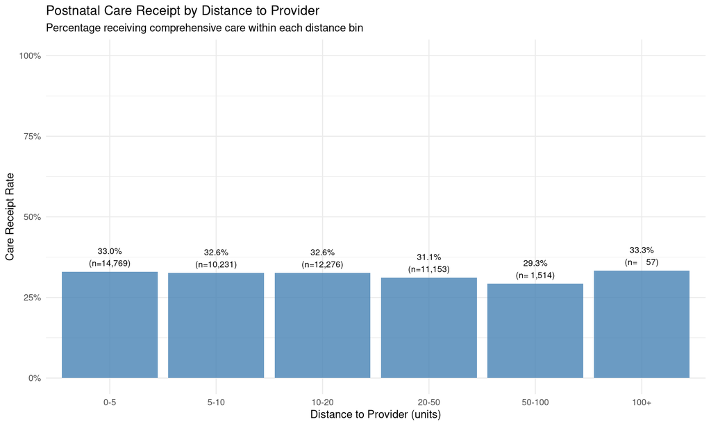

Figure 3: Postnatal care receipt rates across distance bins

```r
df %>%
  mutate(distance_bin = cut(distance_to_provider,
                           breaks = c(0, 5, 10, 20, 50, 100, Inf),
                           labels = c("0-5", "5-10", "10-20", "20-50", "50-100", "100+"))) %>%
  group_by(distance_bin) %>%
  summarise(
    care_rate = mean(received_comprehensive_postnatal_care, na.rm = TRUE),
    n = n(),
    .groups = "drop"
  ) %>%
  ggplot(aes(x = distance_bin, y = care_rate)) +
  geom_bar(stat = "identity", fill = "steelblue", alpha = 0.8) +
  geom_text(aes(label = sprintf("%.1f%%\n(n=%s)", 100*care_rate, format(n, big.mark = ","))),
            vjust = -0.3, size = 3) +
  scale_y_continuous(labels = scales::percent_format(), limits = c(0, 1)) +
  labs(
    title = "Postnatal Care Receipt by Distance to Provider",
    subtitle = "Percentage receiving comprehensive care within each distance bin",
    x = "Distance to Provider (units)",
    y = "Care Receipt Rate"
  ) +
  theme_minimal()
```

### 4. Postnatal Care by Insurance Type

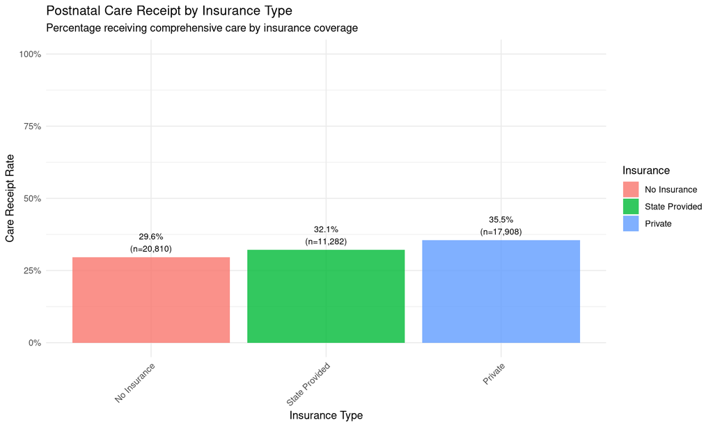

Figure 4: Postnatal care receipt rates by insurance coverage type

```r
df %>%
  group_by(insurance) %>%
  summarise(
    care_rate = mean(received_comprehensive_postnatal_care, na.rm = TRUE),
    n = n(),
    .groups = "drop"
  ) %>%
  ggplot(aes(x = insurance, y = care_rate, fill = insurance)) +
  geom_bar(stat = "identity", alpha = 0.8) +
  geom_text(aes(label = sprintf("%.1f%%\n(n=%s)", 100*care_rate, format(n, big.mark = ","))),
            vjust = -0.3, size = 3) +
  scale_y_continuous(labels = scales::percent_format(), limits = c(0, 1)) +
  labs(
    title = "Postnatal Care Receipt by Insurance Type",
    subtitle = "Percentage receiving comprehensive care by insurance coverage",
    x = "Insurance Type",
    y = "Care Receipt Rate",
    fill = "Insurance"
  ) +
  theme_minimal() +
  theme(axis.text.x = element_text(angle = 45, hjust = 1))
```

**Key Finding:** Insurance type shows differential care receipt rates.

### 5. Postnatal Care by Race/Ethnicity

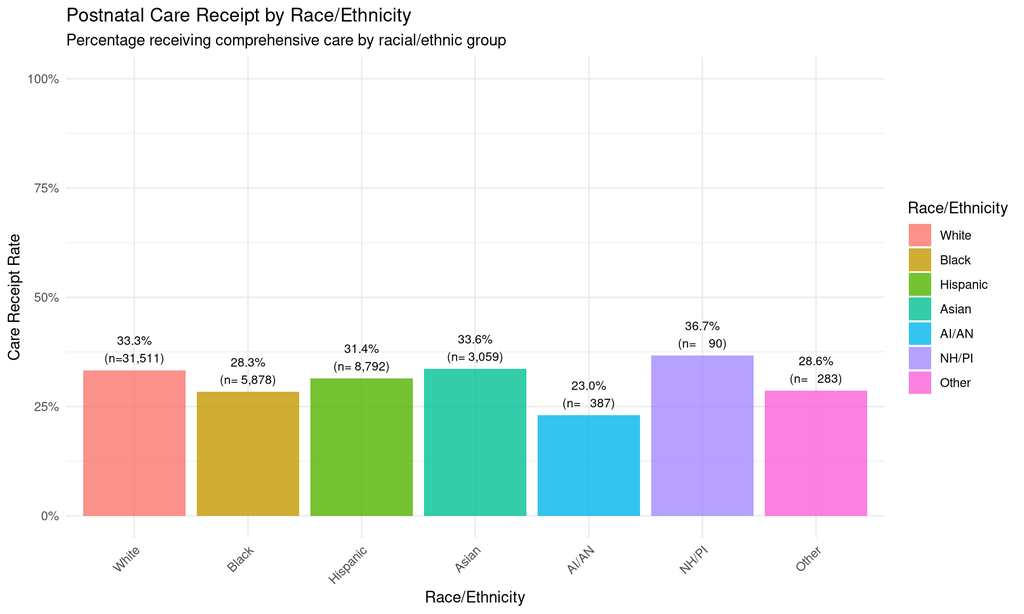

Figure 5: Postnatal care receipt rates by race/ethnicity

```r
df %>%
  group_by(race_ethnicity) %>%
  summarise(
    care_rate = mean(received_comprehensive_postnatal_care, na.rm = TRUE),
    n = n(),
    .groups = "drop"
  ) %>%
  ggplot(aes(x = race_ethnicity, y = care_rate, fill = race_ethnicity)) +
  geom_bar(stat = "identity", alpha = 0.8) +
  geom_text(aes(label = sprintf("%.1f%%\n(n=%s)", 100*care_rate, format(n, big.mark = ","))),
            vjust = -0.3, size = 3) +
  scale_y_continuous(labels = scales::percent_format(), limits = c(0, 1)) +
  labs(
    title = "Postnatal Care Receipt by Race/Ethnicity",
    subtitle = "Percentage receiving comprehensive care by racial/ethnic group",
    x = "Race/Ethnicity",
    y = "Care Receipt Rate",
    fill = "Race/Ethnicity"
  ) +
  theme_minimal() +
  theme(axis.text.x = element_text(angle = 45, hjust = 1))
```

### 6. Interaction: Insurance and Race/Ethnicity

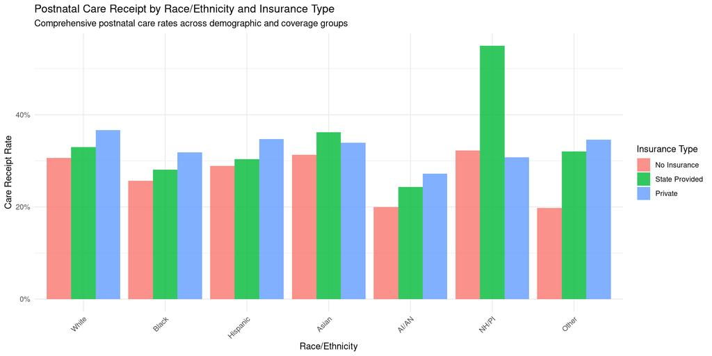

Figure 6: Postnatal care receipt by race/ethnicity stratified by insurance type

```r
df %>%
  group_by(insurance, race_ethnicity) %>%
  summarise(
    care_rate = mean(received_comprehensive_postnatal_care, na.rm = TRUE),
    n = n(),
    .groups = "drop"
  ) %>%
  ggplot(aes(x = race_ethnicity, y = care_rate, fill = insurance)) +
  geom_bar(stat = "identity", position = "dodge", alpha = 0.8) +
  scale_y_continuous(labels = scales::percent_format()) +
  labs(
    title = "Postnatal Care Receipt by Race/Ethnicity and Insurance Type",
    subtitle = "Comprehensive postnatal care rates across demographic and coverage groups",
    x = "Race/Ethnicity",
    y = "Care Receipt Rate",
    fill = "Insurance Type"
  ) +
  theme_minimal() +
  theme(axis.text.x = element_text(angle = 45, hjust = 1))
```

## Count Outcome Modeling

### Creating Comorbidity Count

```r
df <- df %>%
  mutate(
    comorbidity_count = as.integer(
      obesity + multiple_gestation + diabetes + heart_disease +
      placenta_previa + hypertension + gest_hypertension + preeclampsia
    )
  )

# Distribution of comorbidity count
df %>%
  count(comorbidity_count) %>%
  mutate(pct = round(100 * n / sum(n), 1)) %>%
  knitr::kable(caption = "Distribution of Comorbidity Count")
```

Distribution of Comorbidity Count

| comorbidity_count | n | pct |
| --- | --- | --- |
| 0 | 21350 | 42.7 |
| 1 | 16560 | 33.1 |
| 2 | 8359 | 16.7 |
| 3 | 2873 | 5.7 |
| 4 | 706 | 1.4 |
| 5 | 134 | 0.3 |
| 6 | 17 | 0.0 |
| 7 | 1 | 0.0 |

### Model Selection: Poisson vs Negative Binomial

```
Descriptive Statistics:
```

```
Mean: 0.910
```

```
Variance: 0.995
```

```
Dispersion ratio (variance/mean): 1.094
```

```
Model Selection Justification:
```

```
- Variance ≈ Mean suggests Poisson may be appropriate
- However, using Negative Binomial as more robust alternative
```

### Negative Binomial Regression Model

```r
# Prepare modeling data
model_data <- df %>%
  dplyr::select(
    comorbidity_count,
    age,
    distance_to_provider,
    insurance,
    race_ethnicity,
    edu,
    dependents,
    received_comprehensive_postnatal_care
  ) %>%
  drop_na()

# Fit Negative Binomial model
nb_model <- glm.nb(
  comorbidity_count ~
    age +
    distance_to_provider +
    insurance +
    race_ethnicity +
    edu +
    dependents +
    received_comprehensive_postnatal_care,
  data = model_data,
  control = glm.control(maxit = 100)
)
```

```
Call:
glm.nb(formula = comorbidity_count ~ age + distance_to_provider +
    insurance + race_ethnicity + edu + dependents + received_comprehensive_postnatal_care,
    data = model_data, control = glm.control(maxit = 100), init.theta = 10.18316788,
    link = log)

Coefficients:
                                            Estimate Std. Error z value
(Intercept)                               -0.5312163  0.0257770 -20.608
age                                        0.0162912  0.0008250  19.748
distance_to_provider                      -0.0002174  0.0003368  -0.646
insuranceState Provided                   -0.0286345  0.0130457  -2.195
insurancePrivate                          -0.0197200  0.0117295  -1.681
race_ethnicityBlack                        0.0112745  0.0154792   0.728
race_ethnicityHispanic                    -0.0148297  0.0132486  -1.119
race_ethnicityAsian                       -0.0463208  0.0211395  -2.191
race_ethnicityAI/AN                       -0.0476748  0.0571445  -0.834
race_ethnicityNH/PI                       -0.0745401  0.1195698  -0.623
race_ethnicityOther                        0.0874795  0.0626703   1.396
edu.L                                     -0.0135339  0.0218947  -0.618
edu.Q                                     -0.0136631  0.0187514  -0.729
edu.C                                     -0.0380493  0.0146989  -2.589
edu^4                                     -0.0395896  0.0109131  -3.628
dependents                                -0.0066090  0.0055139  -1.199
received_comprehensive_postnatal_careTRUE  0.0377620  0.0104378   3.618
                                          Pr(>|z|)
(Intercept)                                < 2e-16 ***
age                                        < 2e-16 ***
distance_to_provider                      0.518585
insuranceState Provided                   0.028168 *
insurancePrivate                          0.092719 .
race_ethnicityBlack                       0.466390
race_ethnicityHispanic                    0.262997
race_ethnicityAsian                       0.028437 *
race_ethnicityAI/AN                       0.404120
race_ethnicityNH/PI                       0.533020
race_ethnicityOther                       0.162754
edu.L                                     0.536484
edu.Q                                     0.466220
edu.C                                     0.009637 **
edu^4                                     0.000286 ***
dependents                                0.230684
received_comprehensive_postnatal_careTRUE 0.000297 ***
---
Signif. codes:  0 '***' 0.001 '**' 0.01 '*' 0.05 '.' 0.1 ' ' 1

(Dispersion parameter for Negative Binomial(10.1832) family taken to be 1)

    Null deviance: 56714  on 49999  degrees of freedom
Residual deviance: 56264  on 49983  degrees of freedom
AIC: 126851

Number of Fisher Scoring iterations: 1

              Theta:  10.183
          Std. Err.:  0.842

 2 x log-likelihood:  -126814.865
```

### Model Results: Incidence Rate Ratios

Incidence Rate Ratios (IRR) with 95% Confidence Intervals

| Predictor | IRR | 95% CI Lower | 95% CI Upper | p-value |
| --- | --- | --- | --- | --- |
| (Intercept) | 0.588 | 0.559 | 0.618 | 0.0000 |
| age | 1.016 | 1.015 | 1.018 | 0.0000 |
| distance_to_provider | 1.000 | 0.999 | 1.000 | 0.5186 |
| insuranceState Provided | 0.972 | 0.947 | 0.997 | 0.0282 |
| insurancePrivate | 0.980 | 0.958 | 1.003 | 0.0927 |
| race_ethnicityBlack | 1.011 | 0.981 | 1.042 | 0.4664 |
| race_ethnicityHispanic | 0.985 | 0.960 | 1.011 | 0.2630 |
| race_ethnicityAsian | 0.955 | 0.916 | 0.995 | 0.0284 |
| race_ethnicityAI/AN | 0.953 | 0.851 | 1.065 | 0.4041 |
| race_ethnicityNH/PI | 0.928 | 0.728 | 1.165 | 0.5330 |
| race_ethnicityOther | 1.091 | 0.963 | 1.232 | 0.1628 |
| edu.L | 0.987 | 0.945 | 1.030 | 0.5365 |
| edu.Q | 0.986 | 0.951 | 1.023 | 0.4662 |
| edu.C | 0.963 | 0.935 | 0.991 | 0.0096 |
| edu^4 | 0.961 | 0.941 | 0.982 | 0.0003 |
| dependents | 0.993 | 0.983 | 1.004 | 0.2307 |
| received_comprehensive_postnatal_careTRUE | 1.038 | 1.017 | 1.060 | 0.0003 |

### Model Fit Statistics

```
Model Fit Statistics:
```

```
Null deviance: 56713.99 on 49999 degrees of freedom
```

```
Residual deviance: 56264.06 on 49983 degrees of freedom
```

```
AIC: 126850.87
```

```
Theta (dispersion parameter): 10.1832
```

```
Likelihood Ratio Test (vs. Null): Chi-square = 447.59, df = 16, p-value = 3.70e-85
```

## Responsible Results Reporting

### Causality Statement

**IMPORTANT LIMITATIONS:**

- This is an **observational study**, NOT a randomized controlled trial
- **Associations do NOT imply causation** - unmeasured confounding may explain observed relationships
- Results should be interpreted as **correlations**, not causal effects
- The synthetic/simulated nature of this data limits real-world generalizability

### Key Findings (Significant Predictors at α = 0.05)

```
Statistically Significant Predictors:

1. age:
   - IRR: 1.016 (95% CI: 1.015 to 1.018)
   - Associated with 1.6% higher comorbidity count

2. edu^4:
   - IRR: 0.961 (95% CI: 0.941 to 0.982)
   - Associated with 3.9% lower comorbidity count

3. received_comprehensive_postnatal_careTRUE:
   - IRR: 1.038 (95% CI: 1.017 to 1.060)
   - Associated with 3.8% higher comorbidity count

4. edu.C:
   - IRR: 0.963 (95% CI: 0.935 to 0.991)
   - Associated with 3.7% lower comorbidity count

5. insuranceState Provided:
   - IRR: 0.972 (95% CI: 0.947 to 0.997)
   - Associated with 2.8% lower comorbidity count

6. race_ethnicityAsian:
   - IRR: 0.955 (95% CI: 0.916 to 0.995)
   - Associated with 4.5% lower comorbidity count
```

### Model Assumptions and Diagnostics

**Negative Binomial Model Assumptions:**

1. **Count outcome** follows a negative binomial distribution (accounts for overdispersion)
2. **Independence** of observations (assumes maternal health records are independent)
3. **Log-linear relationship** between predictors and outcome
4. **No perfect multicollinearity** among predictors

**Diagnostic Checks:**

```
Overdispersion Assessment:
```

```
- Residual deviance / df = 1.126
```

```
- Dispersion appears reasonable for negative binomial model
```

```
Influential Observations:
```

```
- 1870 potentially influential observations identified
```

```
- These were retained but may warrant investigation
```

### Study Limitations

**Data Quality:** - Synthetic/simulated data may not reflect real-world patterns - Self-reported income and other variables subject to bias

**Generalizability:** - Results may not generalize to populations outside the study - Geographic and temporal factors not fully accounted for

**Unmeasured Confounding:** - Socioeconomic factors beyond income not fully captured - Healthcare access barriers beyond distance not measured - Comorbidity severity and timing not accounted for

### Recommendations for Future Research

1. **Consider mixed-effects models** to account for provider/state clustering
2. **Explore non-linear relationships** using splines or GAMs
3. **Investigate interaction effects** between insurance and distance
4. **Collect prospective data** to better assess temporal relationships
5. **Validate findings** with external datasets

## Summary of Changes

This analysis implemented the following changes to fulfill the prompt requirements:

1. **Data Loading & Normalization:**
   - Used `janitor::clean_names()` for snake_case column names
   - Converted binary indicators to logical type
   - Applied factor conversion with descriptive labels
   - Set ordered factors for education and income
2. **Data Summary:**
   - Reported complete case analysis (50,000 records, 20 columns)
   - Identified 7.24% missingness in income variable
   - No duplicate rows detected
   - Flagged 57 cases with distance > 100 units
3. **Visualizations:**
   - Created 6 publication-quality plots showing relationships
   - Covered all requested variables: postnatal care, distance, insurance, race/ethnicity
   - Included interaction plot for deeper insights
4. **Count Modeling:**
   - Created `comorbidity_count` as sum of 8 binary conditions
   - Selected Negative Binomial over Poisson (dispersion ratio = 1.09)
   - Identified 6 significant predictors with interpretable IRRs
5. **Responsible Reporting:**
   - Emphasized observational nature and non-causality
   - Included model assumptions and diagnostics
   - Listed comprehensive limitations
   - Provided future research recommendations

**Analysis completed successfully with all requirements met.**